# LinearRegression

## Some vocabulary

**Linear regression** is a simple way to mathematically model the relationship between two or more observed phenomena.

Ex: age, height

We always designate one, and only one of our observations to be the **outcome variable** although you may also hear it referred to as the `response`, `dependent variable` or even simply $\mathbf{y}$. All other observations are termed **predictors** although you may also hear them referred to as the `independent variables`, `regressors`, `covariates`, `features`, `the data`, or even “the $X$ matrix”

## Example: predict petal length with sepal measurements

Our linear model:

$$\begin{equation}
\underbrace{\text{petal length}}_{y} = \beta_0 + \beta_1 \underbrace{\text{sepal length}}_{x_{1}} + \beta_2 \underbrace{\text{sepal width}}_{x_{2}}
\end{equation}$$

```r
X = iris[, c("Sepal.Length","Sepal.Width")] # predictors
y = iris[,c("Petal.Length")] # outcome
```

What does a linear model look like geometrically?

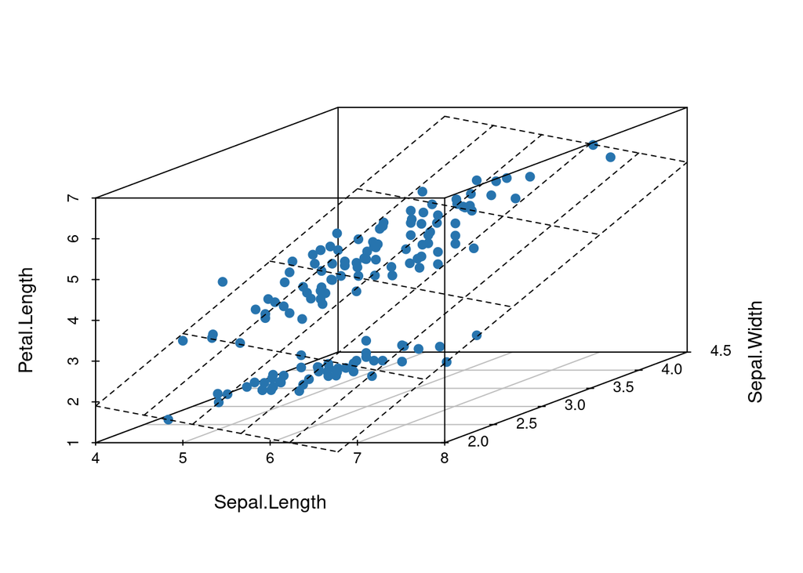

```r
plot3d = scatterplot3d(iris[,1:3], pch = 19, color=uclaBlue)
model  = lm(y ~ X[,1] + X[,2])
plot3d$plane3d(model)
```

What’s linear about this model?

The “linear’’ in”linear regression" refers to the fact that we are interested in predicting some outcome variable by taking a linear combination of predictors. You can transform the data any way you like.

Example: we could transform to use log(sepal length) and (sepal width)$^2$:

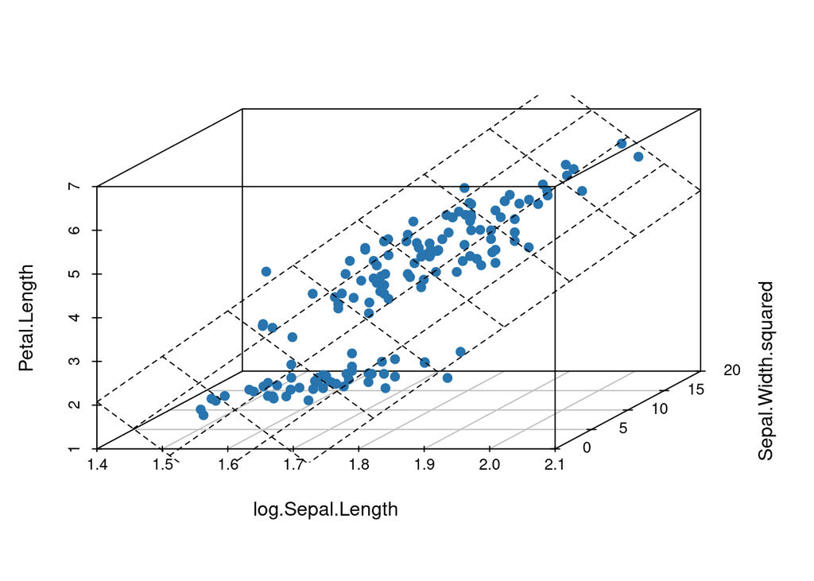

```r
log.Sepal.Length = log(iris[,1])
Sepal.Width.squared = iris[,2]^2
Petal.Length = iris[,3]

plot3d = scatterplot3d(log.Sepal.Length, Sepal.Width.squared, Petal.Length, pch = 19, color=uclaBlue)
model  = lm(Petal.Length ~ log.Sepal.Length + Sepal.Width.squared)
plot3d$plane3d(model)
```

Linear regression is about estimating $\boldsymbol{\beta}$ to find the “best” hyperplane. But how do we find/define the “best” $\boldsymbol{\beta}$?

The full model is:
$$y_i = \sum_i x_i \beta_i + \epsilon_i$$
where $\epsilon_i$ is some random noise that interferes with our measurements. It could stand in for a covariate we have not accounted for or it could be actual measurement error. In either case, the most elementary assumption (and still often a useful one) is that
$$\epsilon_i \sim N(0, 1)$$

i.e. the noise the $i$th observation is normally distributed with mean $0$ and variance $1$.

## Hunt for the hyperplane!

To build our model, we start with $X$ and $\mathbf{y}$. We know $X$. We know $\mathbf{y}$. We have a description for $\epsilon$’s distribution. What we don’t know and want to estimate is $\beta$. If our model is correct, (and it’s not, but suspend disbelief for now!) then $\beta$ has some true value that is unknown to us. In order to distinguish our estimate for $\beta$ from the true value, we will give **our estimate** a new name: “beta hat”, $\hat{\beta}$, (because it wears a hat).

The actual “model” model that we will use for making future predictions about petal length is
$$\mathbf{\hat{y}} = X \hat{\beta}$$

How do we find $\hat{\beta}$?

By choosing an **objective function**. An objective function is some criteria we care about minimizing or maximizing (in other words, “optimizing”) and it’s what makes one hyperplane better than all the rest.

Let’s turn our attention to one common objective function known as “least squares”.

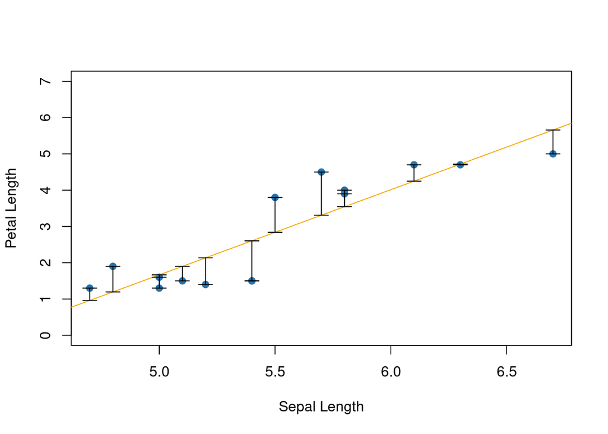

```r
set.seed(28)
indices = sample(100,15)
x = iris[indices,1]
y = iris[indices,3]
westWoodGold = rgb(matrix(c(242/255, 169/255, 0), ncol = 3, nrow = 1))
plot(x, y, pch=19, col = uclaBlue, xlab="Sepal Length", ylab="Petal Length", ylim=c(0,7)) # plot points
model  = lm(y ~ x)
beta_hat = rev(model$coefficients) # estimated coefficients
y_hat = x*beta_hat[1] + beta_hat[2] # OLS best fit line
abline(beta_hat[2], beta_hat[1], col = westWoodGold) # add line to plot
arrows(x, y, x, y_hat, length = 0.08, angle = 90, code = 3)
```

Each vertical line is known as an error bar and shows the residual error, $\epsilon$. In other words each vertical line displays the difference between our prediction, $\hat{y} = X \hat{\beta}$, and our observations: $y = X \beta + \epsilon$.

Naturally, we wish to minimize the error in our prediction. How might we formulate our desire mathematically? We could try to minimize $\sum_{i=1}^n \epsilon_i$, but if we think about it, this will not work well. Why? Because large positive errors will offset large negative errors to yield an overall *small* sum of errors. One remedy that arises is to minimize $\sum_{i=1}^n | \epsilon_i |$, and this is a viable option known as least absolute value (LAV) regression. Here, however, we will unpack the canonical “least squares” method. It is important to understand that we must $\underline{\text{choose}}$ the objective function that we want to optimize.

The least squares objective function:
$$\sum_{i=1}^n \epsilon_i ^2 = \left( y_i - x_1 \beta_1 - x_2 \beta_2 - \ldots - x_n \beta_n
- \beta_{n+1} \right)^2$$
is known as the **residual sum of squares** but you may also see it called the “sum of squared residuals”. What do we know in the above equation? What are we trying to “optimize over”? How do you think we would write this in vector notation?

# Appendix

## Matrix algebra essentials

#### Matrix elements and transpose

Matrix $A$ has elements $a_{ij}$. $i$ denotes the row and $j$ denotes the column of the element, e.g.
$$\begin{equation}
A
=
\begin{bmatrix}
a_{11} & a_{12} & a_{13}\\
a_{21} & a_{22} & a_{23}\\
a_{31} & a_{32} & a_{33}
\end{bmatrix}
\end{equation}$$

The transpose of a matrix, takes each element $a_{ij}$ and places it in the spot of $a_{ji}$, e.g.
$$\begin{equation}
A ^T
=
\begin{bmatrix}
a_{11} & a_{21} & a_{31}\\
a_{12} & a_{22} & a_{23}\\
a_{13} & a_{23} & a_{33}
\end{bmatrix}
\end{equation}$$
Notice that the diagonals remain the same and the off-diagonals switch places. If $A$ and $B$ are matrices then the transpose of their product is:
$$\begin{equation}
(AB) ^T = B ^T A ^T
\end{equation}$$

#### Matrix vector multiplication

Multiplying a matrix by a vector means you are taking a linear combination of the columns of the matrix. In other words,
$$\begin{equation}
\begin{bmatrix}
1 & 1\\
2 & 1\\
3 & 1
\end{bmatrix}
\begin{bmatrix}
\beta_1\\
\beta_2
\end{bmatrix}
=
\beta_1
\begin{bmatrix}
1 \\
2 \\
3
\end{bmatrix}
+
\beta_2
\begin{bmatrix}
1\\
1\\
1
\end{bmatrix}
\end{equation}$$
To read more about matrix mulitiplication, see [wikipedia’s article on matrix multiplication](https://en.wikipedia.org/wiki/Matrix_multiplication), there are many different perspectives on this single operation!

#### The identity matrix: $I$ (multiplying by 1)

An identity matrix is a square matrix with $1$s on the diagonal and zeros everywhere else. Multipying any matrix or vector by the appropriately sized identity matrix yields that same matrix or vector, e.g.
$$\begin{equation}
\begin{bmatrix}
1 & 1 & 4\\
2 & 5 & 3\\
3 & 1 & 2
\end{bmatrix}
\times
\underbrace{
\begin{bmatrix}
1 & 0 & 0\\
0 & 1 & 0\\
0 & 0 & 1
\end{bmatrix}
}_{\text{identity matrix: ``I''}}
=
\begin{bmatrix}
1 & 1 & 4\\
2 & 5 & 3\\
3 & 1 & 2
\end{bmatrix}
\end{equation}$$

#### Inverses

A square matrix is a matrix with an equal number of columns and rows.

Some square matrices have inverses, e.g., let $A$ be a matrix. If $A$ has an inverse, it will be denoted $A^{-1}$ and satisfy the property $A A^{-1} = A^{-1} A = I$.

All matrices $B$ of the form $B = A ^T A$ are invertible.

## Least squares optimization

Using the matrix algebra facts above, together with rules for differentiation that can be found in [the matrix cookbook](https://www.math.uwaterloo.ca/~hwolkowi/matrixcookbook.pdf) we will derive the $\hat{\beta}$ that minimizes the residual sum of squares,
$$\begin{equation}
\begin{aligned}
\epsilon ^T \epsilon
&= (y - \hat{y}) ^T (y - \hat{y})\\
&= (y - X \hat{\beta}) ^T (y - X \hat{\beta}).
\end{aligned}
\end{equation}$$
To do this, we will take the derivative with respect to $\hat{\beta}$.
$$\begin{equation}
\newcommand{\gradient}[1]{\frac{\partial}{\partial #1}}
\begin{aligned}
\gradient{\hat{\beta}} \epsilon ^T \epsilon
&=
\gradient{\hat{\beta}} (y - X \hat{\beta}) ^T (y - X \hat{\beta})\\
&= \gradient{\hat{\beta}}
\left[ y ^T y - 2 y ^T X \hat{\beta} + \hat{\beta} ^T X ^T X \hat{\beta} \right]\\
&= -2 y ^T X + 2 \hat{\beta} ^T X ^T X
\end{aligned}
\end{equation}$$
Setting the derivative equal to zero gives us our estimate, $\hat{\beta}$.
$$\begin{equation}
\begin{aligned}
- 2y ^T X + 2 \hat{\beta} ^T X ^T X
&= 0\\
\hat{\beta} ^T X ^T X &= y ^T X\\
\hat{\beta} ^T = y ^T X (X ^T X )^{-1}
\end{aligned}
\end{equation}$$
Transposing both sides, we get:
$$\begin{equation}
\hat{\beta} = (X ^T X)^{-1} X ^T y
\end{equation}$$